# Obesity Prediction

by Federico Gerardi

# Download Dataset

In this section, we download the dataset and split it into training and testing sets.

In this section we download the dataset and we separate train and test sets

```python
import numpy as np # Operations for linear algebra
import math
import pandas as pd # Data processing and reading CSV files using Pandas (e.g., pd.read_csv)
from sklearn import metrics
from sklearn.linear_model import LinearRegression
import matplotlib.pyplot as plt
import seaborn as sns


url='https://drive.google.com/file/d/12dUeEO_rkButPD79pOteFoSSeuIBg5qt/view?usp=drive_link'
file_id=url.split('/')[-2]
dwn_url='https://drive.google.com/uc?id=' + file_id
dataset = pd.read_csv(dwn_url)
```

```python
TRAIN_TEST_SPLIT_PERCENTAGE = 0.9
dataset_training = dataset[:int(len(dataset) * TRAIN_TEST_SPLIT_PERCENTAGE)]
dataset_test = dataset[int(len(dataset) * TRAIN_TEST_SPLIT_PERCENTAGE):]
```

# Linear Regression using the Normal Equation

This section utilizes the normal equation to create a predictive model.

## Data manipulation

In this code block we are manipulating the dataset, removing all the possible strings and replacing them with numbers.

```python
gender_map = {"Male": 0, "Female": 1}

dataset.Gender.replace(gender_map, inplace=True)

y_n_map = {"yes": 1, "no": 0}

dataset.family_history_with_overweight.replace(y_n_map, inplace=True)

dataset.FAVC.replace(y_n_map, inplace=True)
dataset.SMOKE.replace(y_n_map, inplace=True)
dataset.SCC.replace(y_n_map, inplace=True)

times_map = {"no": 0, "Sometimes": 1, "Frequently": 2, "Always": 3}

dataset.CAEC.replace(times_map, inplace=True)
dataset.CALC.replace(times_map, inplace=True)

trans_map = {"Public_Transportation": 3, "Walking": 0, "Automobile": 4, "Motorbike": 2, "Bike": 1}

dataset.MTRANS.replace(trans_map, inplace=True)

obesity_map = {"Insufficient_Weight": 0, "Normal_Weight": 1, "Overweight_Level_I": 2, "Overweight_Level_II": 3, "Obesity_Type_I": 4, "Obesity_Type_II": 5, "Obesity_Type_III": 6}

dataset.NObeyesdad.replace(obesity_map, inplace=True)

dataset
```

|  | Gender | Age | Height | Weight | family_history_with_overweight | FAVC | FCVC | NCP | CAEC | SMOKE | CH2O | SCC | FAF | TUE | CALC | MTRANS | NObeyesdad |
| --- | --- | --- | --- | --- | --- | --- | --- | --- | --- | --- | --- | --- | --- | --- | --- | --- | --- |
| 0 | 1 | 21.000000 | 1.620000 | 64.000000 | 1 | 0 | 2.0 | 3.0 | 1 | 0 | 2.000000 | 0 | 0.000000 | 1.000000 | 0 | 3 | 1 |
| 1 | 1 | 21.000000 | 1.520000 | 56.000000 | 1 | 0 | 3.0 | 3.0 | 1 | 1 | 3.000000 | 1 | 3.000000 | 0.000000 | 1 | 3 | 1 |
| 2 | 0 | 23.000000 | 1.800000 | 77.000000 | 1 | 0 | 2.0 | 3.0 | 1 | 0 | 2.000000 | 0 | 2.000000 | 1.000000 | 2 | 3 | 1 |
| 3 | 0 | 27.000000 | 1.800000 | 87.000000 | 0 | 0 | 3.0 | 3.0 | 1 | 0 | 2.000000 | 0 | 2.000000 | 0.000000 | 2 | 0 | 2 |
| 4 | 0 | 22.000000 | 1.780000 | 89.800000 | 0 | 0 | 2.0 | 1.0 | 1 | 0 | 2.000000 | 0 | 0.000000 | 0.000000 | 1 | 3 | 3 |
| ... | ... | ... | ... | ... | ... | ... | ... | ... | ... | ... | ... | ... | ... | ... | ... | ... | ... |
| 2106 | 1 | 20.976842 | 1.710730 | 131.408528 | 1 | 1 | 3.0 | 3.0 | 1 | 0 | 1.728139 | 0 | 1.676269 | 0.906247 | 1 | 3 | 6 |
| 2107 | 1 | 21.982942 | 1.748584 | 133.742943 | 1 | 1 | 3.0 | 3.0 | 1 | 0 | 2.005130 | 0 | 1.341390 | 0.599270 | 1 | 3 | 6 |
| 2108 | 1 | 22.524036 | 1.752206 | 133.689352 | 1 | 1 | 3.0 | 3.0 | 1 | 0 | 2.054193 | 0 | 1.414209 | 0.646288 | 1 | 3 | 6 |
| 2109 | 1 | 24.361936 | 1.739450 | 133.346641 | 1 | 1 | 3.0 | 3.0 | 1 | 0 | 2.852339 | 0 | 1.139107 | 0.586035 | 1 | 3 | 6 |
| 2110 | 1 | 23.664709 | 1.738836 | 133.472641 | 1 | 1 | 3.0 | 3.0 | 1 | 0 | 2.863513 | 0 | 1.026452 | 0.714137 | 1 | 3 | 6 |

2111 rows × 17 columns

Let's separate training set and test set with a 90% proportion.

Also we shuffle data.

```python
sh_dataset = dataset.sample(frac=1).reset_index(drop=True)  # Shuffle the dataset to randomize order
dataset_training = sh_dataset[:int(len(dataset) * TRAIN_TEST_SPLIT_PERCENTAGE)]
dataset_test = sh_dataset[int(len(dataset) * TRAIN_TEST_SPLIT_PERCENTAGE):]
```

We build the x matrix and y vector of training and test

X matrix has the bias in the first column and contains the whole dataset except the weight one.

Y vector contains only the weight column.

```python
# Training
y = dataset_training.Weight
y = y.to_numpy()

x = dataset_training.copy()
del x["Weight"]
x = x.to_numpy()

bias = np.ones(shape=(len(x), 1))
x = np.concatenate((bias, x), axis=1)

# Test
y_test = dataset_test.Weight.reset_index(drop=True)
x_test = dataset_test.copy()
del x_test["Weight"]
x_test = x_test.to_numpy()
bias = np.ones(shape=(len(x_test), 1))
x_test = np.concatenate((bias, x_test), axis=1)
```

## Training

Calculation of the pseudoinverse.

```python
c = np.linalg.pinv(x)@y
```

Compare the value with the Sklearn one

## Testing

```python
model = LinearRegression()

model.fit(x, y)

y_sk = model.predict(x_test)

print(f"Our MSE: {metrics.mean_squared_error(x_test@c, y_test)}\t RMSE: {np.sqrt(metrics.mean_squared_error(x_test@c, y_test))}\t MAE: {metrics.mean_absolute_error(x_test@c, y_test)}")
print(f"Sklearn MSE: {metrics.mean_squared_error(y_sk, y_test)}\t RMSE: {np.sqrt(metrics.mean_squared_error(y_sk, y_test))}\t MAE: {metrics.mean_absolute_error(y_sk, y_test)}")
```

```
Our MSE: 26.014091235970646	 RMSE: 5.100401085794199	 MAE: 3.9527638148680007
Sklearn MSE: 26.014091235970586	 RMSE: 5.100401085794194	 MAE: 3.952763814868014
```

Similar result

# Linear regression with Gradient Descent

## Data manipulation

Same code that you can find before

```python
gender_map = {"Male": 0, "Female": 1}

dataset.Gender.replace(gender_map, inplace=True)

y_n_map = {"yes": 1, "no": 0}

dataset.family_history_with_overweight.replace(y_n_map, inplace=True)

dataset.FAVC.replace(y_n_map, inplace=True)
dataset.SMOKE.replace(y_n_map, inplace=True)
dataset.SCC.replace(y_n_map, inplace=True)

times_map = {"no": 0, "Sometimes": 1, "Frequently": 2, "Always": 3}

dataset.CAEC.replace(times_map, inplace=True)
dataset.CALC.replace(times_map, inplace=True)

trans_map = {"Public_Transportation": 3, "Walking": 0, "Automobile": 4, "Motorbike": 2, "Bike": 1}

dataset.MTRANS.replace(trans_map, inplace=True)

obesity_map = {"Insufficient_Weight": 0, "Normal_Weight": 1, "Overweight_Level_I": 2, "Overweight_Level_II": 3, "Obesity_Type_I": 4, "Obesity_Type_II": 5, "Obesity_Type_III": 6}

dataset.NObeyesdad.replace(obesity_map, inplace=True)

dataset

sh_dataset = dataset.sample(frac=1).reset_index(drop=True)  # Shuffle the dataset to randomize order
dataset_training = sh_dataset[:int(len(dataset) * TRAIN_TEST_SPLIT_PERCENTAGE)]
dataset_test = sh_dataset[int(len(dataset) * TRAIN_TEST_SPLIT_PERCENTAGE):]

# Training
y = dataset_training.Weight
y = y.to_numpy()

x = dataset_training.copy()
del x["Weight"]
x = x.to_numpy()

bias = np.ones(shape=(len(x), 1))
x = np.concatenate((bias, x), axis=1)

# Test
y_test = dataset_test.Weight.reset_index(drop=True)
x_test = dataset_test.copy()
del x_test["Weight"]
x_test = x_test.to_numpy()
bias = np.ones(shape=(len(x_test), 1))
x_test = np.concatenate((bias, x_test), axis=1)
```

## Function definition

Gradient descent to find the minimum of the MSE

```python
def linear_regression_gradient_descent(x, y, alpha, epochs):
  _, N = np.shape(x)

  c = np.random.rand(N,)

  for i in range(epochs):
    x_c = (x @ c)
    grad = (x.T @ (x_c - y)) / N

    c = c - alpha * grad

    print(f"epoch: {i}\t error: {metrics.mean_squared_error(x@c, y)}")

  return c
```

2 Hyperparameters:

- Alpha
- Epochs

## Training

GridSearch with some hyperparameters.

```python
hyperparameters = [
    {
        'alpha': 10e-6,
        'epochs': 10000
    },
    {
        'alpha': 10e-6,
        'epochs': 100000
    },
    {
        'alpha': 10e-6,
        'epochs': 100
    }
]

c_list = list()

for params in hyperparameters:
  c = linear_regression_gradient_descent(x, y, params['alpha'], params['epochs'])
  c_list.append(c)
```

```
Streaming output truncated to the last 5000 lines.
epoch: 95100	 error: 50.391255873663084
epoch: 95101	 error: 50.391205337904935
epoch: 95102	 error: 50.39115480233207
epoch: 95103	 error: 50.39110426694449
epoch: 95104	 error: 50.391053731742154
epoch: 95105	 error: 50.3910031967251
epoch: 95106	 error: 50.390952661893294
epoch: 95107	 error: 50.390902127246754
epoch: 95108	 error: 50.39085159278545
epoch: 95109	 error: 50.39080105850939
epoch: 95110	 error: 50.390750524418564
epoch: 95111	 error: 50.39069999051297
epoch: 95112	 error: 50.39064945679261
epoch: 95113	 error: 50.390598923257464
epoch: 95114	 error: 50.39054838990753
epoch: 95115	 error: 50.39049785674281
epoch: 95116	 error: 50.3904473237633
epoch: 95117	 error: 50.39039679096899
epoch: 95118	 error: 50.39034625835986
epoch: 95119	 error: 50.390295725935935
epoch: 95120	 error: 50.39024519369718
epoch: 95121	 error: 50.39019466164362
epoch: 95122	 error: 50.390144129775216
epoch: 95123	 error: 50.390093598092
epoch: 95124	 error: 50.390043066593925
epoch: 95125	 error: 50.38999253528102
epoch: 95126	 error: 50.38994200415326
epoch: 95127	 error: 50.38989147321066
epoch: 95128	 error: 50.38984094245319
epoch: 95129	 error: 50.38979041188086
epoch: 95130	 error: 50.38973988149367
epoch: 95131	 error: 50.389689351291594
epoch: 95132	 error: 50.389638821274644
epoch: 95133	 error: 50.38958829144281
epoch: 95134	 error: 50.38953776179607
epoch: 95135	 error: 50.38948723233445
epoch: 95136	 error: 50.389436703057925
epoch: 95137	 error: 50.3893861739665
epoch: 95138	 error: 50.38933564506016
```

[output cut: 4946 more lines]

```
epoch: 85	 error: 424.0054505977895
epoch: 86	 error: 421.27204645130405
epoch: 87	 error: 418.56180539589803
epoch: 88	 error: 415.8745290131089
epoch: 89	 error: 413.21002059033316
epoch: 90	 error: 410.56808510612905
epoch: 91	 error: 407.94852921564893
epoch: 92	 error: 405.3511612361949
epoch: 93	 error: 402.77579113290085
epoch: 94	 error: 400.2222305045365
epoch: 95	 error: 397.6902925694353
epoch: 96	 error: 395.17979215154253
epoch: 97	 error: 392.69054566658406
epoch: 98	 error: 390.2223711083555
epoch: 99	 error: 387.77508803512757
```

## Testing

Test models, comparing them with sklearn ones.

```python
model = LinearRegression()

model.fit(x, y)

y_sk = model.predict(x_test)


min_mse = [100000000, 0]

for i in range(len(hyperparameters)):
  mse = metrics.mean_squared_error(x_test@c_list[i], y_test)
  print(f"C[{i}] MSE: {mse}\t RMSE: {np.sqrt(mse)}\t MAE: {metrics.mean_absolute_error(x_test@c_list[i], y_test)}")
  if mse < min_mse[0]:
    min_mse = [mse, i]

print(f'The best model is the #{min_mse[1]} using alpha={hyperparameters[min_mse[1]]["alpha"]} and epochs={hyperparameters[min_mse[1]]["epochs"]} with MSE: {min_mse[0]}')
print(f"Sklearn MSE: {metrics.mean_squared_error(y_sk, y_test)}\t RMSE: {np.sqrt(metrics.mean_squared_error(y_sk, y_test))}\t MAE: {metrics.mean_absolute_error(y_sk, y_test)}")
```

```
C[0] MSE: 64.64465362626626	 RMSE: 8.040189899888327	 MAE: 6.444044891340923
C[1] MSE: 48.932388085097	 RMSE: 6.995168910405024	 MAE: 5.569443258077282
C[2] MSE: 353.94777746193006	 RMSE: 18.81349987274909	 MAE: 14.148220172729852
The best model is the #1 using alpha=1e-05 and epochs=100000 with MSE: 48.932388085097
Sklearn MSE: 26.190369925039008	 RMSE: 5.11765277495836	 MAE: 3.8657440260232643
```

# Linear Regression with Stochastic Gradient Descent

## Data Manipulation

```python
gender_map = {"Male": 0, "Female": 1}

dataset.Gender.replace(gender_map, inplace=True)

y_n_map = {"yes": 1, "no": 0}

dataset.family_history_with_overweight.replace(y_n_map, inplace=True)

dataset.FAVC.replace(y_n_map, inplace=True)
dataset.SMOKE.replace(y_n_map, inplace=True)
dataset.SCC.replace(y_n_map, inplace=True)

times_map = {"no": 0, "Sometimes": 1, "Frequently": 2, "Always": 3}

dataset.CAEC.replace(times_map, inplace=True)
dataset.CALC.replace(times_map, inplace=True)

trans_map = {"Public_Transportation": 3, "Walking": 0, "Automobile": 4, "Motorbike": 2, "Bike": 1}

dataset.MTRANS.replace(trans_map, inplace=True)

obesity_map = {"Insufficient_Weight": 0, "Normal_Weight": 1, "Overweight_Level_I": 2, "Overweight_Level_II": 3, "Obesity_Type_I": 4, "Obesity_Type_II": 5, "Obesity_Type_III": 6}

dataset.NObeyesdad.replace(obesity_map, inplace=True)

dataset

sh_dataset = dataset.sample(frac=1).reset_index(drop=True)  # Shuffle the dataset to randomize order
dataset_training = sh_dataset[:int(len(dataset) * TRAIN_TEST_SPLIT_PERCENTAGE)]
dataset_test = sh_dataset[int(len(dataset) * TRAIN_TEST_SPLIT_PERCENTAGE):]

# Training
y = dataset_training.Weight
y = y.to_numpy()

x = dataset_training.copy()
del x["Weight"]
x = x.to_numpy()

bias = np.ones(shape=(len(x), 1))
x = np.concatenate((bias, x), axis=1)

# Test
y_test = dataset_test.Weight.reset_index(drop=True)
x_test = dataset_test.copy()
del x_test["Weight"]
x_test = x_test.to_numpy()
bias = np.ones(shape=(len(x_test), 1))
x_test = np.concatenate((bias, x_test), axis=1)
```

## Function Definition

Same but with mini-batches

```python
def linear_regression_sgd(x, y, alpha, batch_size, epochs):
  _, N = np.shape(x)

  c = np.random.rand(N,)

  epochs = epochs * batch_size

  x_split = np.array_split(x, batch_size)
  y_split = np.array_split(y, batch_size)

  for i in range(epochs):
    x_c = (x_split[i % batch_size] @ c)
    grad = (x_split[i % batch_size].T @ (x_c - y_split[i % batch_size])) / N

    c = c - alpha * grad

    if i % batch_size == 0:
      print(f"epoch: {i/batch_size}\t error: {metrics.mean_squared_error(x@c, y)}")


  return c
```

3 hyperparameters:

- alpha
- mini batch size
- epoches

## Training

```python
hyperparameters = [
    {
        'alpha': 10e-6,
        'batch_size': 9,
        'epochs': 500
    },
    {
        'alpha': 10e-6,
        'batch_size': 18,
        'epochs': 100
    },
    {
        'alpha': 10e-6,
        'batch_size': 20,
        'epochs': 100
    }
]

c_list = list()

for params in hyperparameters:
  c = linear_regression_sgd(x, y, params['alpha'], params['batch_size'], params['epochs'])
  c_list.append(c)
```

```
epoch: 0.0	 error: 3362.5296749140734
epoch: 1.0	 error: 1293.5481879535873
epoch: 2.0	 error: 860.0213544302268
epoch: 3.0	 error: 765.6032738602397
epoch: 4.0	 error: 741.6495891721321
epoch: 5.0	 error: 732.4215651847669
epoch: 6.0	 error: 726.3238870804641
epoch: 7.0	 error: 720.9303999184697
epoch: 8.0	 error: 715.7270135929444
epoch: 9.0	 error: 710.6017682956017
epoch: 10.0	 error: 705.5288135032762
epoch: 11.0	 error: 700.5014258626209
epoch: 12.0	 error: 695.5174341393995
epoch: 13.0	 error: 690.5758800084476
epoch: 14.0	 error: 685.6761804962085
epoch: 15.0	 error: 680.8178881088273
epoch: 16.0	 error: 676.000610952074
epoch: 17.0	 error: 671.2239824497519
epoch: 18.0	 error: 666.4876488176868
epoch: 19.0	 error: 661.7912636162295
epoch: 20.0	 error: 657.1344853145656
epoch: 21.0	 error: 652.5169761813721
epoch: 22.0	 error: 647.9384017695423
epoch: 23.0	 error: 643.3984306691722
epoch: 24.0	 error: 638.8967343821928
epoch: 25.0	 error: 634.4329872523182
epoch: 26.0	 error: 630.0068664202296
epoch: 27.0	 error: 625.61805179033
epoch: 28.0	 error: 621.2662260028725
epoch: 29.0	 error: 616.9510744086377
epoch: 30.0	 error: 612.6722850448755
epoch: 31.0	 error: 608.4295486119313
epoch: 32.0	 error: 604.2225584502918
epoch: 33.0	 error: 600.0510105179218
epoch: 34.0	 error: 595.9146033678418
epoch: 35.0	 error: 591.8130381259185
epoch: 36.0	 error: 587.746018468854
epoch: 37.0	 error: 583.7132506023672
epoch: 38.0	 error: 579.7144432395652
epoch: 39.0	 error: 575.7493075794993
```

[output cut: 645 more lines]

```
epoch: 85.0	 error: 437.8570754882172
epoch: 86.0	 error: 435.05439081673694
epoch: 87.0	 error: 432.27523009013885
epoch: 88.0	 error: 429.5193936005669
epoch: 89.0	 error: 426.78668334247766
epoch: 90.0	 error: 424.076902998096
epoch: 91.0	 error: 421.3898579229949
epoch: 92.0	 error: 418.72535513179804
epoch: 93.0	 error: 416.08320328400674
epoch: 94.0	 error: 413.4632126699456
epoch: 95.0	 error: 410.8651951968305
epoch: 96.0	 error: 408.28896437495445
epoch: 97.0	 error: 405.73433530399245
epoch: 98.0	 error: 403.20112465942276
epoch: 99.0	 error: 400.6891506790651
```

## Testing

```python
model = LinearRegression()

model.fit(x, y)

y_sk = model.predict(x_test)


min_mse = [100000000, 0]

for i in range(len(hyperparameters)):
  mse = metrics.mean_squared_error(x_test@c_list[i], y_test)
  print(f"C[{i}] MSE: {mse}\t RMSE: {np.sqrt(mse)}\t MAE: {metrics.mean_absolute_error(x_test@c_list[i], y_test)}")
  if mse < min_mse[0]:
    min_mse = [mse, i]

print(f'The best model is the #{min_mse[1]} using alpha={hyperparameters[min_mse[1]]["alpha"]} and epochs={hyperparameters[min_mse[1]]["epochs"]} with MSE: {min_mse[0]}')
print(f"Sklearn MSE: {metrics.mean_squared_error(y_sk, y_test)}\t RMSE: {np.sqrt(metrics.mean_squared_error(y_sk, y_test))}\t MAE: {metrics.mean_absolute_error(y_sk, y_test)}")
```

```
C[0] MSE: 98.26334836365095	 RMSE: 9.912787113806639	 MAE: 8.319715238964498
C[1] MSE: 330.42800632862793	 RMSE: 18.177678793746686	 MAE: 13.98772957464574
C[2] MSE: 353.3230189584122	 RMSE: 18.796888544607913	 MAE: 14.510641409527114
The best model is the #0 using alpha=1e-05 and epochs=500 with MSE: 98.26334836365095
Sklearn MSE: 24.57662652425599	 RMSE: 4.957481873315927	 MAE: 3.8171129235029087
```

# Learn decision tree

## Data Manipulation

Classification data manipulation

```python
url='https://drive.google.com/file/d/12dUeEO_rkButPD79pOteFoSSeuIBg5qt/view?usp=drive_link'
file_id=url.split('/')[-2]
dwn_url='https://drive.google.com/uc?id=' + file_id
dataset = pd.read_csv(dwn_url)

TRAIN_TEST_SPLIT_PERCENTAGE = 0.9
dataset_training = dataset[:int(len(dataset) * TRAIN_TEST_SPLIT_PERCENTAGE)]
dataset_test = dataset[int(len(dataset) * TRAIN_TEST_SPLIT_PERCENTAGE):]

gender_map = {"Male": 0, "Female": 1}

dataset.Gender.replace(gender_map, inplace=True)

y_n_map = {"yes": 1, "no": 0}

dataset.family_history_with_overweight.replace(y_n_map, inplace=True)

dataset.FAVC.replace(y_n_map, inplace=True)
dataset.SMOKE.replace(y_n_map, inplace=True)
dataset.SCC.replace(y_n_map, inplace=True)

times_map = {"no": 0, "Sometimes": 1, "Frequently": 2, "Always": 3}

dataset.CAEC.replace(times_map, inplace=True)
dataset.CALC.replace(times_map, inplace=True)

trans_map = {"Public_Transportation": 3, "Walking": 0, "Automobile": 4, "Motorbike": 2, "Bike": 1}

dataset.MTRANS.replace(trans_map, inplace=True)

obesity_map = {"Insufficient_Weight": 0, "Normal_Weight": 0, "Overweight_Level_I": 0, "Overweight_Level_II": 0, "Obesity_Type_I": 1, "Obesity_Type_II": 1, "Obesity_Type_III": 1}

dataset.NObeyesdad.replace(obesity_map, inplace=True)

dataset['Height'] = dataset['Height'].apply(lambda x : x * 10)

dataset = dataset.astype({"Age": "int", "Height": "int", "Weight": "int", "FCVC": "int", "NCP": "int", "CH2O": "int", "FAF": "int", "TUE": "int"})

sh_dataset = dataset.sample(frac=1).reset_index(drop=True)  # Shuffle the dataset to randomize order
dataset_training = sh_dataset[:int(len(dataset) * TRAIN_TEST_SPLIT_PERCENTAGE)]
dataset_test = sh_dataset[int(len(dataset) * TRAIN_TEST_SPLIT_PERCENTAGE):]


dataset
```

|  | Gender | Age | Height | Weight | family_history_with_overweight | FAVC | FCVC | NCP | CAEC | SMOKE | CH2O | SCC | FAF | TUE | CALC | MTRANS | NObeyesdad |
| --- | --- | --- | --- | --- | --- | --- | --- | --- | --- | --- | --- | --- | --- | --- | --- | --- | --- |
| 0 | 1 | 21 | 16 | 64 | 1 | 0 | 2 | 3 | 1 | 0 | 2 | 0 | 0 | 1 | 0 | 3 | 0 |
| 1 | 1 | 21 | 15 | 56 | 1 | 0 | 3 | 3 | 1 | 1 | 3 | 1 | 3 | 0 | 1 | 3 | 0 |
| 2 | 0 | 23 | 18 | 77 | 1 | 0 | 2 | 3 | 1 | 0 | 2 | 0 | 2 | 1 | 2 | 3 | 0 |
| 3 | 0 | 27 | 18 | 87 | 0 | 0 | 3 | 3 | 1 | 0 | 2 | 0 | 2 | 0 | 2 | 0 | 0 |
| 4 | 0 | 22 | 17 | 89 | 0 | 0 | 2 | 1 | 1 | 0 | 2 | 0 | 0 | 0 | 1 | 3 | 0 |
| ... | ... | ... | ... | ... | ... | ... | ... | ... | ... | ... | ... | ... | ... | ... | ... | ... | ... |
| 2106 | 1 | 20 | 17 | 131 | 1 | 1 | 3 | 3 | 1 | 0 | 1 | 0 | 1 | 0 | 1 | 3 | 1 |
| 2107 | 1 | 21 | 17 | 133 | 1 | 1 | 3 | 3 | 1 | 0 | 2 | 0 | 1 | 0 | 1 | 3 | 1 |
| 2108 | 1 | 22 | 17 | 133 | 1 | 1 | 3 | 3 | 1 | 0 | 2 | 0 | 1 | 0 | 1 | 3 | 1 |
| 2109 | 1 | 24 | 17 | 133 | 1 | 1 | 3 | 3 | 1 | 0 | 2 | 0 | 1 | 0 | 1 | 3 | 1 |
| 2110 | 1 | 23 | 17 | 133 | 1 | 1 | 3 | 3 | 1 | 0 | 2 | 0 | 1 | 0 | 1 | 3 | 1 |

2111 rows × 17 columns

## Class definition

Two classes:

- Attribute: Contains the name of the attribute and all its possible values
- DecisionTree: The Tree

```python
class Attribute:
  name = str()
  values = []
  def __init__(self, name, values):
    self.name = name
    self.values = values  # []

  def __str__(self):
    return self.name


class DecisionTree:
  attribute = None
  subtree = []
  def __init__(self, attribute):
    self.attribute = attribute  # Attribute
    self.subtrees = []  # [(DecisionTree, value)]


  def add_sub(self, subtree):
    self.subtrees.append(subtree)
```

Useful functions

```python
def get_examples_set(examples, attribute, value):
  result = []

  for e in examples:
    if e[attribute] == value:
      result.append(e)

  return result

def remove_attribute_from_set(attributes, A):
  result = attributes.copy()
  result.remove(A)
  return result


def count_yes(examples):
  count = 0
  for e in examples:
    if e[len(e)-1]:
      count += 1

  return count

def count_no(examples):
  count = 0

  for e in examples:
    if not e[len(e)-1]:
      count += 1

  return count

def plurality_value(examples, attributes):
  return int(count_yes(examples) > count_no(examples))


def same_classification(examples):
  return int(count_yes(examples) == 0 or count_no(examples) == 0)


def B(q):
  if q == 0:
    return 0
  return -(q*np.log2(q)+(1-q)*np.log2(1-q))

def Remainder(A, index_a, examples):
  ret = 0
  for v in A.values:
    exs = get_examples_set(examples, index_a, v)
    if len(exs) > 2:
      ret += ((count_yes(exs) + count_no(exs))/(len(examples)))*B(count_yes(exs)/(len(examples)))

  return ret

def max_importance(attributes, examples):
  max_i = 0
  max_A = None
  for a in attributes:
    i = B(count_yes(examples)/(len(examples))) - Remainder(a, attributes.index(a), examples)
    if i > max_i:
      max_i = i
      max_A = a

  return max_A
```

Gready Algorithm implemented

```python
def learn_decision_tree (examples, attributes, parent_examples):
  if len(examples) == 0:
    return plurality_value(parent_examples, attributes)
  elif same_classification(examples):
    return examples[0][-1]
  elif len(attributes) == 0:
    return plurality_value(examples, attributes)
  else:
    A = max_importance(attributes, examples)
    tree = DecisionTree(A)
    for v in A.values:
      exs = get_examples_set(examples, attributes.index(A), v)
      subtree = learn_decision_tree(exs, remove_attribute_from_set(attributes, A), examples)
      tree.add_sub((subtree, v))

  return tree
```

## Testing

Build the tree and calculate the accuracy

```
Accuracy: 0.9198113207547169
Precision: 0.9310344827586207
Recall: 0.8804347826086957
F1: 0.9050279329608939
ROC AUC: 0.9152173913043479
False positives: [11  6]
False negatives: [ 6 11]
```

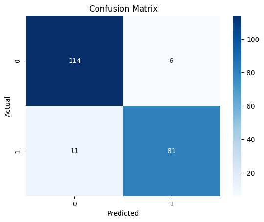

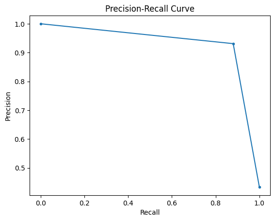

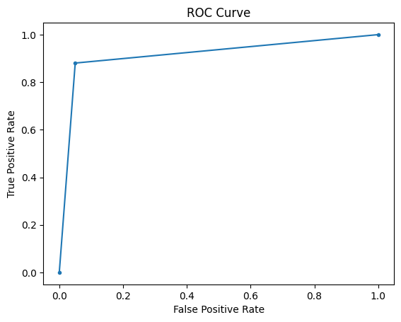

```python
attribute_array = [
    Attribute("Gender", [0, 1]),
    Attribute("Age", range(14, 62)),
    Attribute("Height", range(14, 20)),
    Attribute("Weight", range(39, 174)),
    Attribute("family_history_with_overweight", [0, 1]),
    Attribute("FAVC", [0, 1]),
    Attribute("FCVC", [1, 2, 3]),
    Attribute("NCP", [1, 2, 3, 4]),
    Attribute("CAEC", [0, 1, 2, 3]),
    Attribute("SMOKE", [0, 1]),
    Attribute("CH2O", [1, 2, 3]),
    Attribute("SCC", [0, 1]),
    Attribute("FAF", [0, 1, 2, 3]),
    Attribute("TUE", [0, 1, 2]),
    Attribute("CALC", [0, 1, 2, 3]),
    Attribute("MTRANS", [0, 1, 2, 3, 4]),
    Attribute("NObeyesdad", [0, 1])
]


dec_tree = learn_decision_tree(dataset_training.to_numpy(), attribute_array, None)



def print_decision_tree(tree, h):
  if type(tree[0]) != DecisionTree:
    if type(tree[0]) == np.int64 or type(tree[0]) == int:
      print("  " * h + f"|_{tree[1]}_", tree[0])
      return


  print("  " * h + f"|_{tree[1]}_", tree[0].attribute.name)

  for sub in tree[0].subtrees:
    print_decision_tree(sub, h+1)



def predict_decision_tree(x, tree, attribute_array):
  for sub in tree[0].subtrees:

    if x[attribute_array.index(tree[0].attribute)] == sub[1]:

      if type(sub[0]) == DecisionTree:
        return predict_decision_tree(x, sub, attribute_array)
      else:
        return sub[0]

win = 0
y_pred = np.zeros((dataset_test.shape[0]))
y_test = np.zeros((dataset_test.shape[0]))
i = 0
for x in dataset_test.to_numpy():
  y_pred[i] = predict_decision_tree(x, (dec_tree, 0), attribute_array)
  y_test[i] = x[-1]
  i += 1


cm = metrics.confusion_matrix(y_test, y_pred)

print(f"Accuracy: {metrics.accuracy_score(y_test, y_pred)}")
print(f"Precision: {metrics.precision_score(y_test, y_pred)}")
print(f"Recall: {metrics.recall_score(y_test, y_pred)}")
print(f"F1: {metrics.f1_score(y_test, y_pred)}")
print(f"ROC AUC: {metrics.roc_auc_score(y_test, y_pred)}")
print(f"False positives: {cm.sum(axis=0) - np.diag(cm)}")
print(f"False negatives: {cm.sum(axis=1) - np.diag(cm)}")

plt.figure()
sns.heatmap(cm, annot=True, fmt='d', cmap='Blues')
plt.xlabel('Predicted')
plt.ylabel('Actual')
plt.title('Confusion Matrix')
plt.show()

precision, recall, thresholds = metrics.precision_recall_curve(y_test, y_pred)
plt.figure()
plt.plot(recall, precision, marker='.')
plt.xlabel('Recall')
plt.ylabel('Precision')
plt.title('Precision-Recall Curve')
plt.show()

fpr, tpr, thresholds = metrics.roc_curve(y_test, y_pred)
plt.figure()
plt.plot(fpr, tpr, marker='.')
plt.xlabel('False Positive Rate')
plt.ylabel('True Positive Rate')
plt.title('ROC Curve')
plt.show()
```

# Logistic Regression

## Data Manipulation

```python
gender_map = {"Male": 0, "Female": 1}

dataset.Gender.replace(gender_map, inplace=True)

y_n_map = {"yes": 1, "no": 0}

dataset.family_history_with_overweight.replace(y_n_map, inplace=True)

dataset.FAVC.replace(y_n_map, inplace=True)
dataset.SMOKE.replace(y_n_map, inplace=True)
dataset.SCC.replace(y_n_map, inplace=True)

times_map = {"no": 0, "Sometimes": 1, "Frequently": 2, "Always": 3}

dataset.CAEC.replace(times_map, inplace=True)
dataset.CALC.replace(times_map, inplace=True)

trans_map = {"Public_Transportation": 3, "Walking": 0, "Automobile": 4, "Motorbike": 2, "Bike": 1}

dataset.MTRANS.replace(trans_map, inplace=True)

obesity_map = {"Insufficient_Weight": 0, "Normal_Weight": 0, "Overweight_Level_I": 0, "Overweight_Level_II": 0, "Obesity_Type_I": 1, "Obesity_Type_II": 1, "Obesity_Type_III": 1}

dataset.NObeyesdad.replace(obesity_map, inplace=True)

dataset['Height'] = dataset['Height'].apply(lambda x : x * 10)

dataset = dataset.astype({"Age": "int", "Height": "int", "Weight": "int", "FCVC": "int", "NCP": "int", "CH2O": "int", "FAF": "int", "TUE": "int"})

sh_dataset = dataset.sample(frac=1).reset_index(drop=True)  # Shuffle the dataset to randomize order
dataset_training = sh_dataset[:int(len(dataset) * TRAIN_TEST_SPLIT_PERCENTAGE)]
dataset_test = sh_dataset[int(len(dataset) * TRAIN_TEST_SPLIT_PERCENTAGE):]


dataset
```

|  | Gender | Age | Height | Weight | family_history_with_overweight | FAVC | FCVC | NCP | CAEC | SMOKE | CH2O | SCC | FAF | TUE | CALC | MTRANS | NObeyesdad |
| --- | --- | --- | --- | --- | --- | --- | --- | --- | --- | --- | --- | --- | --- | --- | --- | --- | --- |
| 0 | 1 | 21 | 160 | 64 | 1 | 0 | 2 | 3 | 1 | 0 | 2 | 0 | 0 | 1 | 0 | 3 | 0 |
| 1 | 1 | 21 | 150 | 56 | 1 | 0 | 3 | 3 | 1 | 1 | 3 | 1 | 3 | 0 | 1 | 3 | 0 |
| 2 | 0 | 23 | 180 | 77 | 1 | 0 | 2 | 3 | 1 | 0 | 2 | 0 | 2 | 1 | 2 | 3 | 0 |
| 3 | 0 | 27 | 180 | 87 | 0 | 0 | 3 | 3 | 1 | 0 | 2 | 0 | 2 | 0 | 2 | 0 | 0 |
| 4 | 0 | 22 | 170 | 89 | 0 | 0 | 2 | 1 | 1 | 0 | 2 | 0 | 0 | 0 | 1 | 3 | 0 |
| ... | ... | ... | ... | ... | ... | ... | ... | ... | ... | ... | ... | ... | ... | ... | ... | ... | ... |
| 2106 | 1 | 20 | 170 | 131 | 1 | 1 | 3 | 3 | 1 | 0 | 1 | 0 | 1 | 0 | 1 | 3 | 1 |
| 2107 | 1 | 21 | 170 | 133 | 1 | 1 | 3 | 3 | 1 | 0 | 2 | 0 | 1 | 0 | 1 | 3 | 1 |
| 2108 | 1 | 22 | 170 | 133 | 1 | 1 | 3 | 3 | 1 | 0 | 2 | 0 | 1 | 0 | 1 | 3 | 1 |
| 2109 | 1 | 24 | 170 | 133 | 1 | 1 | 3 | 3 | 1 | 0 | 2 | 0 | 1 | 0 | 1 | 3 | 1 |
| 2110 | 1 | 23 | 170 | 133 | 1 | 1 | 3 | 3 | 1 | 0 | 2 | 0 | 1 | 0 | 1 | 3 | 1 |

2111 rows × 17 columns

```python
# Training
y = dataset_training.NObeyesdad
y = y.to_numpy()

x = dataset_training.copy()
del x["NObeyesdad"]
x = x.to_numpy()

bias = np.ones(shape=(len(x), 1))
x = np.concatenate((bias, x), axis=1)

# Test
y_test = dataset_test.NObeyesdad.reset_index(drop=True)
x_test = dataset_test.copy()
del x_test["NObeyesdad"]
x_test = x_test.to_numpy()
bias = np.ones(shape=(len(x_test), 1))
x_test = np.concatenate((bias, x_test), axis=1)
```

## Function Definition

```python
def logistic_regression_loss(y, y_pred):
  epsilon = 1e-15
  y_pred = np.clip(y_pred, epsilon, 1 - epsilon)

  sum = 0
  for i in range(len(y)):
    sum += (y[i]*np.log2(y_pred[i])) + ((1-y[i])*np.log2(1-y_pred[i]))

  return -(1/len(y))*sum

def logistic_predict(x, c):
  z = x@c
  z = 1/(1+np.exp(-z))
  return np.where(z >= 0.5, 1, 0)

def logistic_regression(x, y, alpha, batch_size, epochs):
  _, N = np.shape(x)

  c = np.random.rand(N,)

  epochs = epochs * batch_size

  x_split = np.array_split(x, batch_size)
  y_split = np.array_split(y, batch_size)

  for i in range(epochs):
    z = x_split[i % batch_size]@c
    logistic = 1/(1+np.exp(-z))
    grad = (logistic - y_split[i % batch_size])@x_split[i % batch_size]

    c = c - alpha * grad

    if i % batch_size == 0:
      print(f"epoch: {int(i/batch_size)}\t error {logistic_regression_loss(y, logistic_predict(x, c))}")

  return c
```

## Training

SGD on Logistic function

```python
hyperparameters = [
    {
        'alpha': 10e-6,
        'batch_size': 9,
        'epochs': 500
    },
    {
        'alpha': 10e-6,
        'batch_size': 18,
        'epochs': 50
    },
    {
        'alpha': 10e-6,
        'batch_size': 20,
        'epochs': 100
    }
]

c_list = list()

for params in hyperparameters:
  c = logistic_regression(x, y, params['alpha'], params['batch_size'], params['epochs'])
  c_list.append(c)
```

```
epoch: 0	 error 26.922410188794057
epoch: 1	 error 6.638679958913459
epoch: 2	 error 6.559958853820821
epoch: 3	 error 6.481240178586524
epoch: 4	 error 6.297560232383572
epoch: 5	 error 6.166360010468069
epoch: 6	 error 6.035161003481736
epoch: 7	 error 5.930201554906836
epoch: 8	 error 5.799001940455919
epoch: 9	 error 5.667801111075831
epoch: 10	 error 5.484120557408294
epoch: 11	 error 5.405401882173996
epoch: 12	 error 5.3004424335990965
epoch: 13	 error 5.116762487396144
epoch: 14	 error 4.933084363586947
epoch: 15	 error 4.723166681366318
epoch: 16	 error 4.618207840256003
epoch: 17	 error 4.434526679123881
epoch: 18	 error 4.119650763257521
epoch: 19	 error 3.831010761015084
epoch: 20	 error 3.699811754028752
epoch: 21	 error 3.699811754028752
epoch: 22	 error 3.6735715881527344
epoch: 23	 error 3.5161324152903846
epoch: 24	 error 3.46365329846752
epoch: 25	 error 3.332452469087432
epoch: 26	 error 3.3062129106759994
epoch: 27	 error 3.2537337938531348
epoch: 28	 error 3.2012546770302697
epoch: 29	 error 3.2012546770302697
epoch: 30	 error 3.0962964433845404
epoch: 31	 error 3.070056884973108
epoch: 32	 error 3.0438173265616757
epoch: 33	 error 3.0438173265616757
epoch: 34	 error 2.991338209738811
epoch: 35	 error 2.9388590929159464
epoch: 36	 error 2.9388590929159464
epoch: 37	 error 2.886379368628497
epoch: 38	 error 2.886379368628497
epoch: 39	 error 2.886379368628497
```

[output cut: 595 more lines]

```
epoch: 85	 error 2.309092074568599
epoch: 86	 error 2.309092074568599
epoch: 87	 error 2.309092074568599
epoch: 88	 error 2.309092074568599
epoch: 89	 error 2.309092074568599
epoch: 90	 error 2.309092074568599
epoch: 91	 error 2.3353316329800315
epoch: 92	 error 2.3353316329800315
epoch: 93	 error 2.3353316329800315
epoch: 94	 error 2.3353316329800315
epoch: 95	 error 2.3353316329800315
epoch: 96	 error 2.3353316329800315
epoch: 97	 error 2.3090914671040137
epoch: 98	 error 2.3090914671040137
epoch: 99	 error 2.3090914671040137
```

## Testing

```
C[0]:
Accuracy: 0.9386792452830188
Precision: 0.9886363636363636
Recall: 0.8787878787878788
F1: 0.9304812834224598
ROC AUC: 0.9349691606328775
False positives: [12  1]
False negatives: [ 1 12]
```

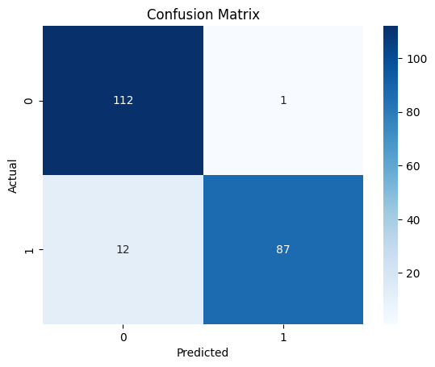

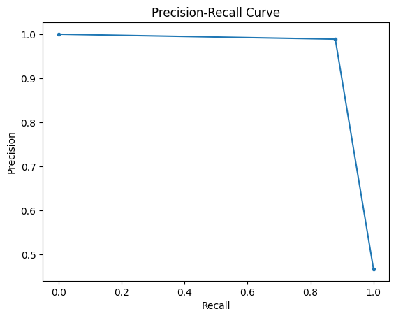

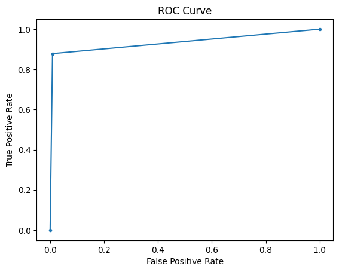

```
C[1]:
Accuracy: 0.9150943396226415
Precision: 0.900990099009901
Recall: 0.9191919191919192
F1: 0.91
ROC AUC: 0.91534817198534
False positives: [ 8 10]
False negatives: [10  8]
```

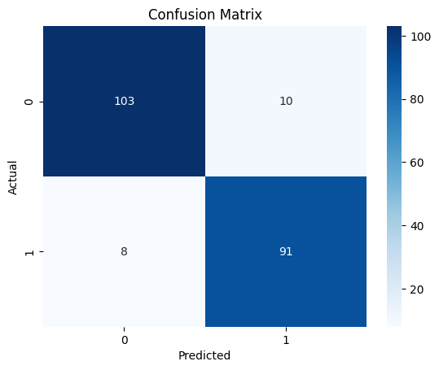

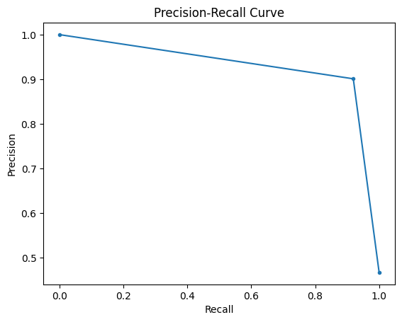

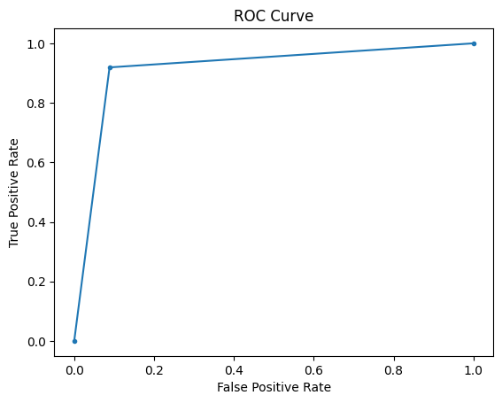

```
C[2]:
Accuracy: 0.9292452830188679
Precision: 0.9375
Recall: 0.9090909090909091
F1: 0.923076923076923
ROC AUC: 0.927996781979083
False positives: [9 6]
False negatives: [6 9]
```

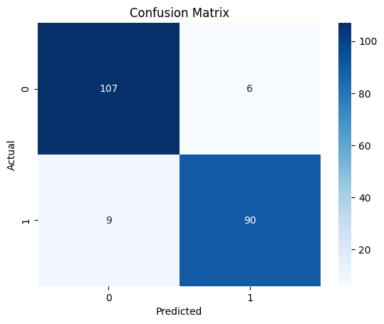

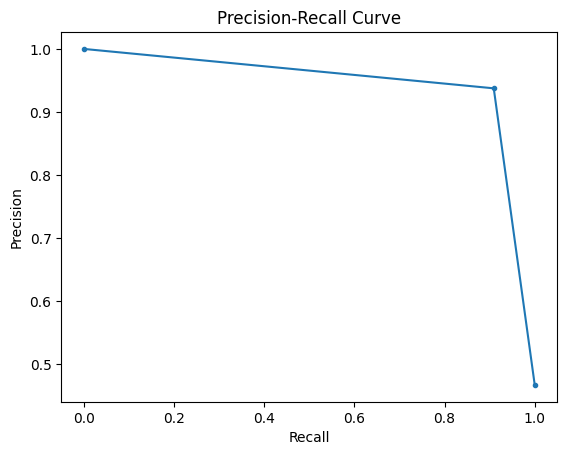

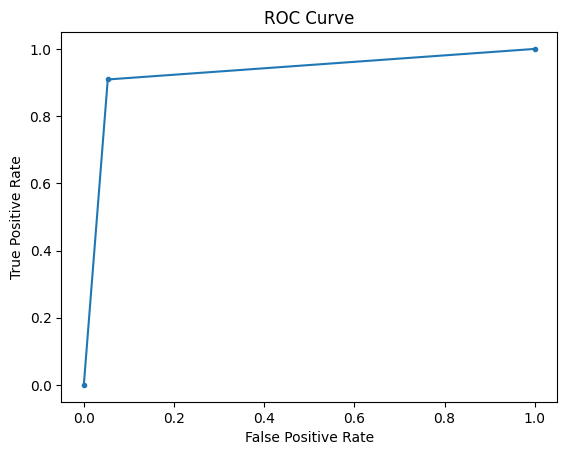

```
The best model is the #0 using alpha=1e-05 and epochs=500 with MSE: 0.9386792452830188
```

```python
max_accuracy = [0, -1]

for i in range(len(hyperparameters)):
  y_pred = logistic_predict(x_test, c_list[i])
  acc = metrics.accuracy_score(y_test, y_pred) # accuracy_logistic_regression(x_test, c_list[i], y_test, 0.5)
  print(f"C[{i}]:")
  cm = metrics.confusion_matrix(y_test, y_pred)

  print(f"Accuracy: {metrics.accuracy_score(y_test, y_pred)}")
  print(f"Precision: {metrics.precision_score(y_test, y_pred)}")
  print(f"Recall: {metrics.recall_score(y_test, y_pred)}")
  print(f"F1: {metrics.f1_score(y_test, y_pred)}")
  print(f"ROC AUC: {metrics.roc_auc_score(y_test, y_pred)}")
  print(f"False positives: {cm.sum(axis=0) - np.diag(cm)}")
  print(f"False negatives: {cm.sum(axis=1) - np.diag(cm)}")

  plt.figure()
  sns.heatmap(cm, annot=True, fmt='d', cmap='Blues')
  plt.xlabel('Predicted')
  plt.ylabel('Actual')
  plt.title('Confusion Matrix')
  plt.show()

  precision, recall, thresholds = metrics.precision_recall_curve(y_test, y_pred)
  plt.figure()
  plt.plot(recall, precision, marker='.')
  plt.xlabel('Recall')
  plt.ylabel('Precision')
  plt.title('Precision-Recall Curve')
  plt.show()

  fpr, tpr, thresholds = metrics.roc_curve(y_test, y_pred)
  plt.figure()
  plt.plot(fpr, tpr, marker='.')
  plt.xlabel('False Positive Rate')
  plt.ylabel('True Positive Rate')
  plt.title('ROC Curve')
  plt.show()
  if acc > max_accuracy[0]:
    max_accuracy = [acc, i]




print(f'The best model is the #{max_accuracy[1]} using alpha={hyperparameters[max_accuracy[1]]["alpha"]} and epochs={hyperparameters[max_accuracy[1]]["epochs"]} with MSE: {max_accuracy[0]}')
```

# Nearest-Neighbor Model

## Data Manipulation

```python
gender_map = {"Male": 0, "Female": 1}

dataset.Gender.replace(gender_map, inplace=True)

y_n_map = {"yes": 1, "no": 0}

dataset.family_history_with_overweight.replace(y_n_map, inplace=True)

dataset.FAVC.replace(y_n_map, inplace=True)
dataset.SMOKE.replace(y_n_map, inplace=True)
dataset.SCC.replace(y_n_map, inplace=True)

times_map = {"no": 0, "Sometimes": 1, "Frequently": 2, "Always": 3}

dataset.CAEC.replace(times_map, inplace=True)
dataset.CALC.replace(times_map, inplace=True)

trans_map = {"Public_Transportation": 3, "Walking": 0, "Automobile": 4, "Motorbike": 2, "Bike": 1}

dataset.MTRANS.replace(trans_map, inplace=True)

obesity_map = {"Insufficient_Weight": 0, "Normal_Weight": 1, "Overweight_Level_I": 2, "Overweight_Level_II": 3, "Obesity_Type_I": 4, "Obesity_Type_II": 5, "Obesity_Type_III": 6}

dataset.NObeyesdad.replace(obesity_map, inplace=True)

nobes = dataset.NObeyesdad.copy()
del dataset["NObeyesdad"]

dataset_normalized = (dataset - dataset.mean())/dataset.std()
dataset_normalized = pd.concat([dataset_normalized, nobes], axis=1)

sh_dataset = dataset_normalized.sample(frac=1).reset_index(drop=True)  # Shuffle the dataset to randomize order
dataset_training = sh_dataset[:int(len(dataset) * TRAIN_TEST_SPLIT_PERCENTAGE)]
dataset_test = sh_dataset[int(len(dataset) * TRAIN_TEST_SPLIT_PERCENTAGE):]
```

```python
# Training
y = dataset_training.NObeyesdad
y = y.to_numpy()

x = dataset_training.copy()
del x["NObeyesdad"]
x = x.to_numpy()

# Test
y_test = dataset_test.NObeyesdad.reset_index(drop=True)
x_test = dataset_test.copy()
del x_test["NObeyesdad"]
x_test = x_test.to_numpy()
```

## Function Definition

Differents distances

```python
def euclidea(x, y):
  return np.linalg.norm(x - y)

def manhattan(x, y):
  return np.sum(np.abs(x - y))

def cosine(x, y):
  return np.dot(x, y)/(np.linalg.norm(x) + np.linalg.norm(y))


def distance(x, y, p='euclidean'):
  if p == 'euclidean':
      return np.linalg.norm(x - y)
  elif p == 'manhattan':
      return np.sum(np.abs(x - y))
  elif p == 'cosine':
      return np.dot(x, y) / (np.linalg.norm(x) * np.linalg.norm(y))
  else:
      return np.sum(np.abs(x - y) ** p) ** (1/p)
```

Predict function

```python
def most_common(lst):
    return max(set(lst), key=lst.count)

def predict_nn(x_test, x, y, K, p):
  mega_list = []

  for i in range(len(x)):
    dist = distance(x_test, x[i], p) # np.linalg.norm(x_test-x[i])
    mega_list.append((dist, y[i]))


  mega_list.sort()

  min_list = []

  for i in range(K):
    min_list.append(mega_list[i][1])

  return most_common(min_list)

def accuracy_knn(x_test, y_test, x, y, K, p):
  win = 0
  for i in range(len(x_test)):
    y_pred = predict_nn(x_test[i], x, y, K, p)
    if y_pred == y_test[i]:
      win += 1

  return win/len(x_test)
```

## Testing

```python
hyperparameters = [
    {
        'K': 1,
        'P': 'euclidean'
    },
    {
        'K': 2,
        'P': 'manhattan'
    },
    {
        'K': 3,
        'P': 'manhattan'
    },
    {
        'K': 4,
        'P': 'cosine'
    },
    {
        'K': 5,
        'P': 3
    },
    {
        'K': 15,
        'P': 3
    },
    {
        'K': 50,
        'P': 'euclidean'
    }
]


max_accuracy = [0, -1]

for i in range(len(hyperparameters)):
  acc = accuracy_knn(x_test, y_test, x, y, hyperparameters[i]['K'], hyperparameters[i]['P'])
  print(f"Accuracy of hyperparametes[{i}]: {acc}")
  if acc > max_accuracy[0]:
    max_accuracy = [acc, i]


print(f'The best model is the #{max_accuracy[1]} using K={hyperparameters[max_accuracy[1]]["K"]} and p={hyperparameters[max_accuracy[1]]["P"]}')
```

```
Accuracy of hyperparametes[0]: 0.9528301886792453
Accuracy of hyperparametes[1]: 0.9716981132075472
Accuracy of hyperparametes[2]: 0.9764150943396226
Accuracy of hyperparametes[3]: 0.29245283018867924
Accuracy of hyperparametes[4]: 0.9292452830188679
Accuracy of hyperparametes[5]: 0.9386792452830188
Accuracy of hyperparametes[6]: 0.9433962264150944
The best model is the #2 using K=3 and p=manhattan
```

# Neural Network

## Data Manipulation

```python
url='https://drive.google.com/file/d/12dUeEO_rkButPD79pOteFoSSeuIBg5qt/view?usp=drive_link'
file_id=url.split('/')[-2]
dwn_url='https://drive.google.com/uc?id=' + file_id
dataset = pd.read_csv(dwn_url)

TRAIN_TEST_SPLIT_PERCENTAGE = 0.9
dataset_training = dataset[:int(len(dataset) * TRAIN_TEST_SPLIT_PERCENTAGE)]
dataset_test = dataset[int(len(dataset) * TRAIN_TEST_SPLIT_PERCENTAGE):]

gender_map = {"Male": 0, "Female": 1}

dataset.Gender.replace(gender_map, inplace=True)

y_n_map = {"yes": 1, "no": 0}

dataset.family_history_with_overweight.replace(y_n_map, inplace=True)

dataset.FAVC.replace(y_n_map, inplace=True)
dataset.SMOKE.replace(y_n_map, inplace=True)
dataset.SCC.replace(y_n_map, inplace=True)

times_map = {"no": 0, "Sometimes": 1, "Frequently": 2, "Always": 3}

dataset.CAEC.replace(times_map, inplace=True)
dataset.CALC.replace(times_map, inplace=True)

trans_map = {"Public_Transportation": 3, "Walking": 0, "Automobile": 4, "Motorbike": 2, "Bike": 1}

dataset.MTRANS.replace(trans_map, inplace=True)

obesity_map = {"Insufficient_Weight": 0, "Normal_Weight": 1, "Overweight_Level_I": 2, "Overweight_Level_II": 3, "Obesity_Type_I": 4, "Obesity_Type_II": 5, "Obesity_Type_III": 6}

dataset.NObeyesdad.replace(obesity_map, inplace=True)

sh_dataset = dataset.sample(frac=1).reset_index(drop=True)  # Shuffle the dataset to randomize order
dataset_training = sh_dataset[:int(len(dataset) * TRAIN_TEST_SPLIT_PERCENTAGE)]
dataset_test = sh_dataset[int(len(dataset) * TRAIN_TEST_SPLIT_PERCENTAGE):]

# Training
y = dataset_training.Weight
y = y.to_numpy().astype(float)

x = dataset_training.copy()
del x["Weight"]
x = x.to_numpy().astype(float)

# Test
y_test = dataset_test.Weight.reset_index(drop=True)
x_test = dataset_test.copy()
del x_test["Weight"]
x_test = x_test.to_numpy()
```

## Class definition and functions

Activation function

```python
def sigmoid(x):
  return 1/(1+np.exp(-x))

def sigmoid_derivative(x):
  return x * (1 - x)

def relu(x):
  return np.maximum(0, x, dtype='float64')

def relu_derivative(dA, Z):
  dZ = np.array(dA, copy=True)
  dZ[Z <= 0] = 0
  return dZ

def threshold(z, value):
  ris = np.copy(z)
  ris[ris >= value] = 1
  ris[ris < value] = 0
  return ris
```

Neural Network Class

```python
class Layer:
  def __init__(self, nodes, activation=relu, derivative=relu_derivative):
    self.nodes = nodes
    self.activation = activation
    self.derivative = derivative


class NeuralNetwork:
  def __init__(self, layers):
    self.layers = layers    # [Layer(in, activation, derivative), Layer(h1, activation, derivative), Layer(h2, activation, derivative), ..., Layer(out, activation, derivative)]
    self.weights = list()
    self.biases = list()
    self.Z_list = list()
    self.A_list = list()
    self.plot_list = list()

    self.init_weights()



  def init_weights(self):
      for i in range(len(self.layers) - 1):
        input_layer = self.layers[i].nodes
        output_layer = self.layers[i+1].nodes

        std_dev = np.sqrt(2.0 / float(input_layer))

        weight = np.random.randn(output_layer, input_layer) * std_dev
        bias = np.zeros((output_layer, 1))
        self.weights.append(weight)
        self.biases.append(bias)


  def forward_propagation(self, x):
    A = np.asmatrix(np.copy(x), dtype='float64').T

    Z_tmp = list()
    A_tmp = [A]

    for i in range(len(self.layers)-1):
      Z = self.weights[i] @ A + self.biases[i]

      A = self.layers[i].activation(Z)

      A_tmp.append(A)
      Z_tmp.append(Z)

    self.Z_list = Z_tmp
    self.A_list = A_tmp

  def back_propagation(self, y_pred, y):

    dW = list()
    dB = list()


    dA_prev = (y_pred - y)

    for i in reversed(range(len(self.layers)-1)):

        dA_curr = dA_prev

        A_prev = self.A_list[i]
        Z_curr = self.Z_list[i]
        W_curr = self.weights[i]

        dZ_curr = self.layers[i].derivative(dA_curr, Z_curr)

        m = A_prev.shape[1]

        dW_curr = (dZ_curr @ A_prev.T) / m
        dB_curr = np.sum(dZ_curr) / m
        dA_prev = W_curr.T @ dZ_curr

        dW.insert(0, dW_curr)
        dB.insert(0, dB_curr)

    return dW, dB

  def train(self, x_train, y_train, lr, epochs):

    loss_list = list()

    epoch = 0
    while epoch < epochs:

      loss = 0

      dW_list = list()
      dB_list = list()

      for x, y in zip(x_train, y_train):

        self.forward_propagation(x)
        y_pred = self.A_list[-1]

        loss += np.power((y_pred - y), 2) / 2

        dW, dB = self.back_propagation(y_pred, y)

        dW_list.append(dW)
        dB_list.append(dB)

        for i in range(len(self.layers)-1):

          self.weights[i] = self.weights[i] - lr * dW[i]
          self.biases[i] = self.biases[i] -  lr * dB[i]

      loss /= x_train.shape[0]


      loss_list.append(int(loss.item()))

      if epoch == 5:
        loss_avg = int(sum(loss_list)/len(loss_list))
        if loss_avg == int(loss_list[0]):
          print("RESTART")
          epoch = 0
          self.weights = []
          self.init_weights()
          continue

      print(f'Epoch {epoch+1}, Loss: {loss.item()}')
      self.plot_list.append((epoch, loss.item()))

      epoch += 1


  def predict_one(self, x):
    self.forward_propagation(x)
    return float(self.A_list[-1].item())

  def predict_matrix(self, x_test):
    y_pred = list()

    for x in x_test:
      y_pred.append(self.predict_one(x))

    return np.array(y_pred)
```

## Training

```python
hyperparameters = [
    {
        'layers': [Layer(x.shape[1], relu, relu_derivative), Layer(64, relu, relu_derivative), Layer(64, relu, relu_derivative), Layer(1, relu, relu_derivative)],
        'lr': 10e-6,
        'epochs': 10
    },
    {
        'layers': [Layer(x.shape[1], relu, relu_derivative), Layer(128, relu, relu_derivative), Layer(1, relu, relu_derivative)],
        'lr': 10e-6,
        'epochs': 10
    },
    {
        'layers': [Layer(x.shape[1], relu, relu_derivative), Layer(64, relu, relu_derivative), Layer(128, relu, relu_derivative), Layer(64, relu, relu_derivative), Layer(1, relu, relu_derivative)],
        'lr': 10e-6,
        'epochs': 10
    }
]

nns = list()

for params in hyperparameters:
  nn = NeuralNetwork(params['layers'])
  nn.train(x, y, lr=params['lr'], epochs=params['epochs'])
  nns.append(nn)
```

```
Epoch 1, Loss: 4093.7710147069547
Epoch 2, Loss: 4093.7710147069547
Epoch 3, Loss: 4093.7710147069547
Epoch 4, Loss: 4093.7710147069547
Epoch 5, Loss: 4093.7710147069547
RESTART
Epoch 1, Loss: 175.7220606529044
Epoch 2, Loss: 54.148424215195924
Epoch 3, Loss: 47.519843591781765
Epoch 4, Loss: 43.86696468195613
Epoch 5, Loss: 40.379647691422115
Epoch 6, Loss: 37.77366087684438
Epoch 7, Loss: 35.12199356149205
Epoch 8, Loss: 32.038019220248785
Epoch 9, Loss: 30.25001829604012
Epoch 10, Loss: 28.877071132927814
Epoch 1, Loss: 296.63930897750026
Epoch 2, Loss: 79.80600025365054
Epoch 3, Loss: 50.46294255845822
Epoch 4, Loss: 46.38222342891476
Epoch 5, Loss: 43.59130090439032
Epoch 6, Loss: 41.52846921910346
Epoch 7, Loss: 39.8901525692698
Epoch 8, Loss: 38.54603769248915
Epoch 9, Loss: 37.26981400982003
Epoch 10, Loss: 36.1259324830897
Epoch 1, Loss: 173.17444932704046
Epoch 2, Loss: 56.4921728229191
Epoch 3, Loss: 48.36767069633422
Epoch 4, Loss: 43.38104806973569
Epoch 5, Loss: 39.65959812855944
Epoch 6, Loss: 36.523585087671776
Epoch 7, Loss: 33.723045948265
Epoch 8, Loss: 31.655597054037337
Epoch 9, Loss: 29.899433598421485
Epoch 10, Loss: 28.450276627261992
```

## Stats

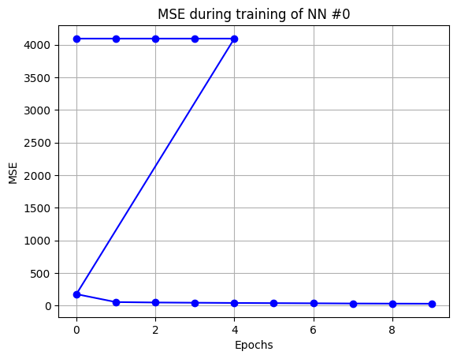

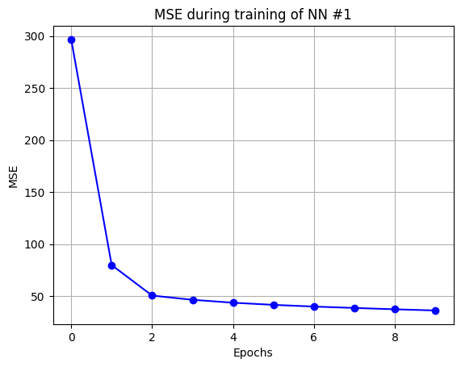

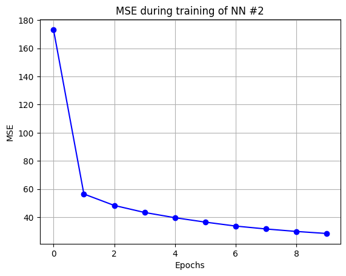

```python
for i in range(len(nns)):
  epochs, loss = zip(*nns[i].plot_list)
  plt.figure()
  plt.plot(epochs, loss, marker='o', linestyle='-', color='b')
  plt.title(f'MSE during training of NN #{i}')
  plt.xlabel('Epochs')
  plt.ylabel('MSE')
  plt.grid(True)
  plt.show()
```

## Testing

```python
min_mse = [100000000, 0]

for i in range(len(nns)):
  y_pred = nns[i].predict_matrix(x_test)
  mse = metrics.mean_squared_error(y_test, y_pred)
  print(f"NN[{i}]:  MSE: {mse}\t RMSE: {np.sqrt(mse)}\t MAE: {metrics.mean_absolute_error(y_test, y_pred)}")
  if mse < min_mse[0]:
    min_mse = [mse, i]

print(f'The best Neural Network is is the #{min_mse[1]} using lr={hyperparameters[min_mse[1]]["lr"]} and epochs={hyperparameters[min_mse[1]]["epochs"]} and layers={[layer.nodes for layer in hyperparameters[min_mse[1]]["layers"]]} with MSE: {min_mse[0]}')
```

```
NN[0]:  MSE: 81.19824809884086	 RMSE: 9.011007052424322	 MAE: 6.976785645659629
NN[1]:  MSE: 93.5714351785433	 RMSE: 9.673232922789738	 MAE: 7.515596020672848
NN[2]:  MSE: 81.30791955664897	 RMSE: 9.01709041524199	 MAE: 7.094462930028252
The best Neural Network is is the #0 using lr=1e-05 and epochs=10 and layers=[16, 64, 64, 1] with MSE: 81.19824809884086
```

## Linear regression

The best linear regression model is the normal equation. For two reasons:

- The speed of computation is almost zero

  > Since there are few features, computing the Moore-Penrose inverse matrix does not require much of resources
- The MSE is identical to Sklearn's.